# Covariance structures with glmmTMB

Kasper Kristensen and Maeve McGillycuddy

2021-05-30

This vignette demonstrates some of the covariance structures available in the `glmmTMB` package. Currently the available covariance structures are:

| Covariance | Notation | Parameter count | Requirement |
| --- | --- | --- | --- |
| Heterogeneous unstructured | `us` | $n(n+1)/2$ |  |
| Heterogeneous Toeplitz | `toep` | $2n-1$ |  |
| Heterogeneous compound symmetry | `cs` | $n+1$ |  |
| Heterogeneous diagonal | `diag` | $n$ |  |
| AR(1) | `ar1` | $2$ | Unit spaced levels |
| Ornstein-Uhlenbeck | `ou` | $2$ | Coordinates |
| Spatial exponential | `exp` | $2$ | Coordinates |
| Spatial Gaussian | `gau` | $2$ | Coordinates |
| Spatial Matern | `mat` | $3$ | Coordinates |
| Reduced rank | `rr` | $nd-d(d-1)/2$ | rank (d) |

The word ‘heterogeneous’ refers to the marginal variances of the model. Beyond correlation parameters, a heterogeneous structure uses $n$ additional variance parameters where $n$ is the dimension.

Some of the structures require temporal or spatial coordinates. We will show examples of this in a later section.

## The AR(1) covariance structure

### Demonstration on simulated data

First, let’s consider a simple time series model. Assume that our measurements $Y(t)$ are given at discrete times $t \in \{1,...,n\}$ by

$$Y(t) = \mu + X(t) + \varepsilon(t)$$

where

- $\mu$ is the mean value parameter.
- $X(t)$ is a stationary AR(1) process, i.e. has covariance $cov(X(s), X(t)) = \sigma^2\exp(-\theta |t-s|)$.
- $\varepsilon(t)$ is iid. $N(0,\sigma_0^2)$ measurement error.

A simulation experiment is set up using the parameters

| Description | Parameter | Value |
| --- | --- | --- |
| Mean | $\mu$ | 0 |
| Process variance | $\sigma^2$ | 1 |
| Measurement variance | $\sigma_0^2$ | 1 |
| One-step correlation | $e^{-\theta}$ | 0.7 |

The following R-code draws a simulation based on these parameter values. For illustration purposes we consider a very short time series.

```r
n <- 6                                              ## Number of time points
x <- mvrnorm(mu = rep(0,n),
             Sigma = .7 ^ as.matrix(dist(1:n)) )    ## Simulate the process using the MASS package
y <- x + rnorm(n)                                   ## Add measurement noise
```

In order to fit the model with `glmmTMB` we must first specify a time variable as a *factor*. The factor *levels* correspond to unit spaced time points. It is a common mistake to forget some factor levels due to missing data or to order the levels incorrectly. We therefore recommend to construct factors with explicit levels, using the `levels` argument to the `factor` function:

```r
times <- factor(1:n, levels=1:n)
levels(times)
```

```
## [1] "1" "2" "3" "4" "5" "6"
```

We also need a grouping variable. In the current case there is only one time-series so the grouping is:

```r
group <- factor(rep(1,n))
```

We combine the data into a single data frame (not absolutely required, but good practice):

```r
dat0 <- data.frame(y,times,group)
```

Now fit the model using

```r
glmmTMB(y ~ ar1(times + 0 | group), data=dat0)
```

This formula notation follows that of the `lme4` package.

- The left hand side of the bar `times + 0` corresponds to a design matrix $Z$ linking observation vector $y$ (rows) with a random effects vector $u$ (columns).
- The distribution of $u$ is `ar1` (this is the only `glmmTMB` specific part of the formula).
- The right hand side of the bar splits the above specification independently among groups. Each group has its own separate $u$ vector but shares the same parameters for the covariance structure.

After running the model, we find the parameter estimates $\mu$ (intercept), $\sigma_0^2$ (dispersion), $\sigma$ (Std. Dev.) and $e^{-\theta}$ (First off-diagonal of “Corr”) in the output:

> FIXME: Try a longer time series when the print.VarCorr is fixed.

```
## Formula:          y ~ ar1(times + 0 | group)
## Data: dat0
##      AIC      BIC   logLik df.resid
## 18.76343 17.93047 -5.38171        2
## Random-effects (co)variances:
##
## Conditional model:
##  Groups   Name   Std.Dev.  Corr
##  group    times1 7.018e-01 -0.58 (ar1)
##  Residual        1.165e-05
##
## Number of obs: 6 / Conditional model: group, 1
##
## Dispersion estimate for gaussian family (sigma^2): 1.36e-10
##
## Fixed Effects:
##
## Conditional model:
## (Intercept)
##       1.072
```

### Increasing the sample size

A single time series of 6 time points is not sufficient to identify the parameters. We could either increase the length of the time series or increase the number of groups. We’ll try the latter:

```r
simGroup <- function(g, n=6, rho=0.7) {
    x <- mvrnorm(mu = rep(0,n),
             Sigma = rho ^ as.matrix(dist(1:n)) )   ## Simulate the process
    y <- x + rnorm(n)                               ## Add measurement noise
    times <- factor(1:n)
    group <- factor(rep(g,n))
    data.frame(y, times, group)
}
simGroup(1)
```

```
##           y times group
## 1 0.3008231     1     1
## 2 0.1835385     2     1
## 3 0.3750261     3     1
## 4 1.5819573     4     1
## 5 1.5776466     5     1
## 6 0.2072020     6     1
```

Generate a dataset with 1000 groups:

```r
dat1 <- do.call("rbind", lapply(1:1000, simGroup) )
```

And fitting the model on this larger dataset gives estimates close to the true values (AR standard deviation=1, residual (measurement) standard deviation=1, autocorrelation=0.7):

```r
(fit.ar1 <- glmmTMB(y ~ ar1(times + 0 | group), data=dat1))
```

```
## Formula:          y ~ ar1(times + 0 | group)
## Data: dat1
##       AIC       BIC    logLik  df.resid
##  20549.90  20576.70 -10270.95      5996
## Random-effects (co)variances:
##
## Conditional model:
##  Groups   Name   Std.Dev. Corr
##  group    times1 1.003    0.72 (ar1)
##  Residual        1.019
##
## Number of obs: 6000 / Conditional model: group, 1000
##
## Dispersion estimate for gaussian family (sigma^2): 1.04
##
## Fixed Effects:
##
## Conditional model:
## (Intercept)
##     0.04378
```

## The unstructured covariance

We can try to fit an unstructured covariance to the previous dataset `dat`. For this case an unstructured covariance has 15 correlation parameters and 6 variance parameters. Adding $\sigma_0^2 I$ on top would cause a strict overparameterization, as these would be redundant with the diagonal elements in the covariance matrix. Hence, when fitting the model with `glmmTMB`, we have to disable the $\varepsilon$ term (the dispersion) by setting `dispformula=~0`:

```r
fit.us <- glmmTMB(y ~ us(times + 0 | group), data=dat1, dispformula=~0)
fit.us$sdr$pdHess ## Converged ?
```

```
## [1] TRUE
```

The estimated variance and correlation parameters are:

```r
VarCorr(fit.us)
```

```
##
## Conditional model:
##  Groups Name   Std.Dev. Corr
##  group  times1 1.4131
##         times2 1.3898   0.353
##         times3 1.5018   0.273 0.384
##         times4 1.4040   0.166 0.216 0.352
##         times5 1.4331   0.160 0.192 0.239 0.354
##         times6 1.4375   0.108 0.136 0.195 0.273 0.345
```

The estimated correlation is approximately constant along diagonals (apparent Toeplitz structure) and we note that the first off-diagonal is now ca. half the true value (0.7) because the dispersion is effectively included in the estimated covariance matrix (i.e. $\rho' = \rho \sigma^2_{{\text {AR}}}/(\sigma^2_{{\text {AR}}} + \sigma^2_{{\text {meas}}})$).

## The Toeplitz structure

The next natural step would be to reduce the number of parameters by collecting correlation parameters within the same off-diagonal. This amounts to 5 correlation parameters and 6 variance parameters.

> FIXME: Explain why dispformula=~1 causes over-parameterization

```r
fit.toep <- glmmTMB(y ~ toep(times + 0 | group), data=dat1, dispformula=~0)
fit.toep$sdr$pdHess ## Converged ?
```

```
## [1] TRUE
```

The estimated variance and correlation parameters are:

```r
(vc.toep <- VarCorr(fit.toep))
```

```
##
## Conditional model:
##  Groups Name   Std.Dev. Corr
##  group  times1 1.4126
##         times2 1.3878   0.358
##         times3 1.4961   0.249 0.358
##         times4 1.4070   0.188 0.249 0.358
##         times5 1.4369   0.148 0.188 0.249 0.358
##         times6 1.4388   0.106 0.148 0.188 0.249 0.358
```

```r
vc1 <- vc.toep$cond[[1]] ## first term of var-cov for RE of conditional model
summary(diag(vc1))
```

```
##    Min. 1st Qu.  Median    Mean 3rd Qu.    Max.
##   1.926   1.984   2.030   2.046   2.069   2.238
```

```r
summary(vc1[row(vc1)!=col(vc1)])
```

```
##    Min. 1st Qu.  Median    Mean 3rd Qu.    Max.
##  0.2159  0.3745  0.5045  0.5119  0.7178  0.7530
```

We can get a *slightly* better estimate of the variance by using REML estimation (however, the estimate of the correlations seems to have gotten slightly worse):

```r
fit.toep.reml <- update(fit.toep, REML=TRUE)
vc1R <- VarCorr(fit.toep.reml)$cond[[1]]
summary(diag(vc1R))
```

```
##    Min. 1st Qu.  Median    Mean 3rd Qu.    Max.
##   1.927   1.984   2.031   2.046   2.069   2.239
```

```r
summary(vc1R[row(vc1R)!=col(vc1R)])
```

```
##    Min. 1st Qu.  Median    Mean 3rd Qu.    Max.
##  0.2167  0.3752  0.5053  0.5127  0.7185  0.7538
```

## Compound symmetry

The compound symmetry structure collects all off-diagonal elements of the correlation matrix to one common value.

> FIXME: Explain why dispformula=~1 causes over-parameterization

```r
fit.cs <- glmmTMB(y ~ cs(times + 0 | group), data=dat1, dispformula=~0)
fit.cs$sdr$pdHess ## Converged ?
```

```
## [1] TRUE
```

The estimated variance and correlation parameters are:

```r
VarCorr(fit.cs)
```

```
##
## Conditional model:
##  Groups Name   Std.Dev. Corr
##  group  times1 1.4312   0.250 (cs)
```

## Anova tables

The models `ar1`, `toep`, and `us` are nested so we can use:

```r
anova(fit.ar1, fit.toep, fit.us)
```

```
## Data: dat1
## Models:
## fit.ar1: y ~ ar1(times + 0 | group), zi=~0, disp=~1
## fit.toep: y ~ toep(times + 0 | group), zi=~0, disp=~0
## fit.us: y ~ us(times + 0 | group), zi=~0, disp=~0
##          Df   AIC   BIC logLik deviance  Chisq Chi Df Pr(>Chisq)
## fit.ar1   4 20550 20577 -10271    20542
## fit.toep 12 20556 20637 -10266    20532 9.4895      8     0.3027
## fit.us   22 20570 20717 -10263    20526 6.5103     10     0.7707
```

`ar1` has the lowest AIC (it’s the simplest model, and fits the data adequately); we can’t reject the (true in this case!) null model that an AR1 structure is adequate to describe the data.

The model `cs` is a sub-model of `toep`:

```r
anova(fit.cs, fit.toep)
```

```
## Data: dat1
## Models:
## fit.cs: y ~ cs(times + 0 | group), zi=~0, disp=~0
## fit.toep: y ~ toep(times + 0 | group), zi=~0, disp=~0
##          Df   AIC   BIC logLik deviance  Chisq Chi Df Pr(>Chisq)
## fit.cs    8 20703 20756 -10343    20687
## fit.toep 12 20556 20637 -10266    20532 154.48      4  < 2.2e-16 ***
## ---
## Signif. codes:  0 '***' 0.001 '**' 0.01 '*' 0.05 '.' 0.1 ' ' 1
```

Here we *can* reject the null hypothesis of compound symmetry (i.e., that all the pairwise correlations are the same).

## Adding coordinate information

Coordinate information can be added to a variable using the `glmmTMB` function `numFactor`. This is necessary in order to use those covariance structures that require coordinates. For example, if we have the numeric coordinates

```r
x <- sample(1:2, 10, replace=TRUE)
y <- sample(1:2, 10, replace=TRUE)
```

we can generate a factor representing $(x,y)$ coordinates by

```r
(pos <- numFactor(x,y))
```

```
##  [1] (2,1) (2,1) (1,1) (2,2) (2,2) (1,2) (2,1) (2,2) (1,1) (2,2)
## Levels: (1,1) (2,1) (1,2) (2,2)
```

Numeric coordinates can be recovered from the factor levels:

```r
parseNumLevels(levels(pos))
```

```
##      [,1] [,2]
## [1,]    1    1
## [2,]    2    1
## [3,]    1    2
## [4,]    2    2
```

In order to try the remaining structures on our test data we re-interpret the time factor using `numFactor`:

```r
dat1$times <- numFactor(dat1$times)
levels(dat1$times)
```

```
## [1] "(1)" "(2)" "(3)" "(4)" "(5)" "(6)"
```

## Ornstein–Uhlenbeck

Having the numeric times encoded in the factor levels we can now try the Ornstein–Uhlenbeck covariance structure.

```r
fit.ou <- glmmTMB(y ~ ou(times + 0 | group), data=dat1)
fit.ou$sdr$pdHess ## Converged ?
```

```
## [1] TRUE
```

It should give the exact same results as `ar1` in this case since the times are equidistant:

```r
VarCorr(fit.ou)
```

```
##
## Conditional model:
##  Groups   Name     Std.Dev. Corr
##  group    times(1) 1.0034
##           times(2) 1.0034   0.721
##           times(3) 1.0034   0.520 0.721
##           times(4) 1.0034   0.375 0.520 0.721
##           times(5) 1.0034   0.270 0.375 0.520 0.721
##           times(6) 1.0034   0.195 0.270 0.375 0.520 0.721
##  Residual          1.0187
```

However, note the differences between `ou` and `ar1`:

- `ou` can handle irregular time points.
- `ou` only allows positive correlation between neighboring time points.

## Spatial correlations

The structures `exp`, `gau` and `mat` are meant to used for spatial data. They all require a Euclidean distance matrix which is calculated internally based on the coordinates. Here, we will try these models on the simulated time series data.

An example with spatial data is presented in a later section.

### Matern

```r
fit.mat <- glmmTMB(y ~ mat(times + 0 | group), data=dat1, dispformula=~0)
fit.mat$sdr$pdHess ## Converged ?
```

```
## [1] TRUE
```

```r
VarCorr(fit.mat)
```

```
##
## Conditional model:
##  Groups Name     Std.Dev. Corr
##  group  times(1) 1.43
##         times(2) 1.43     0.357
##         times(3) 1.43     0.250 0.357
##         times(4) 1.43     0.187 0.250 0.357
##         times(5) 1.43     0.143 0.187 0.250 0.357
##         times(6) 1.43     0.111 0.143 0.187 0.250 0.357
```

### Gaussian

“Gaussian” refers here to a Gaussian decay in correlation with distance, i.e. $\rho = \exp(-d x^2)$, not to the conditional distribution (“family”).

```r
fit.gau <- glmmTMB(y ~ gau(times + 0 | group), data=dat1, dispformula=~0)
fit.gau$sdr$pdHess ## Converged ?
```

```
## [1] TRUE
```

```r
VarCorr(fit.gau)
```

```
##
## Conditional model:
##  Groups Name     Std.Dev. Corr
##  group  times(1) 1.4175
##         times(2) 1.4175   0.280
##         times(3) 1.4175   0.006 0.280
##         times(4) 1.4175   0.000 0.006 0.280
##         times(5) 1.4175   0.000 0.000 0.006 0.280
##         times(6) 1.4175   0.000 0.000 0.000 0.006 0.280
```

### Exponential

```r
fit.exp <- glmmTMB(y ~ exp(times + 0 | group), data=dat1)
fit.exp$sdr$pdHess ## Converged ?
```

```
## [1] TRUE
```

```r
VarCorr(fit.exp)
```

```
##
## Conditional model:
##  Groups   Name     Std.Dev. Corr
##  group    times(1) 1.0034
##           times(2) 1.0034   0.721
##           times(3) 1.0034   0.520 0.721
##           times(4) 1.0034   0.375 0.520 0.721
##           times(5) 1.0034   0.270 0.375 0.520 0.721
##           times(6) 1.0034   0.195 0.270 0.375 0.520 0.721
##  Residual          1.0187
```

### A spatial covariance example

Starting out with the built in `volcano` dataset we reshape it to a `data.frame` with pixel intensity `z` and pixel position `x` and `y`:

```r
d <- data.frame(z = as.vector(volcano),
                x = as.vector(row(volcano)),
                y = as.vector(col(volcano)))
```

Next, add random normal noise to the pixel intensities and extract a small subset of 100 pixels. This is our spatial dataset:

```r
set.seed(1)
d$z <- d$z + rnorm(length(volcano), sd=15)
d <- d[sample(nrow(d), 100), ]
```

Display sampled noisy volcano data:

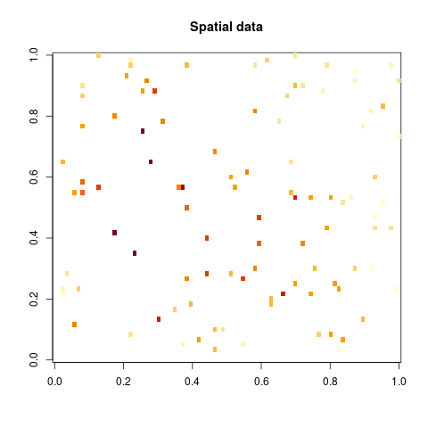

```r
volcano.data <- array(NA, dim(volcano))
volcano.data[cbind(d$x, d$y)] <- d$z
image(volcano.data, main="Spatial data", useRaster=TRUE)
```

Based on this data, we’ll attempt to re-construct the original image.

As model, it is assumed that the original image `image(volcano)` is a realization of a random field with correlation decaying exponentially with distance between pixels.

Denoting by $u(x,y)$ this random field the model for the observations is

$$z_{i} = \mu + u(x_i,y_i) + \varepsilon_i$$

To fit the model, a `numFactor` and a dummy grouping variable must be added to the dataset:

```r
d$pos <- numFactor(d$x, d$y)
d$group <- factor(rep(1, nrow(d)))
```

The model is fit by

```r
f <- glmmTMB(z ~ 1 + exp(pos + 0 | group), data=d)
```

Recall that a standard deviation `sd=15` was used to distort the image. A confidence interval for this parameter is

```r
confint(f, "sigma")
```

```
##          2.5 %   97.5 % Estimate
## sigma 10.61016 18.06028 13.84278
```

The glmmTMB `predict` method can predict unseen levels of the random effects. For instance to predict a 3-by-3 corner of the image one could construct the new data:

```r
newdata <- data.frame( pos=numFactor(expand.grid(x=1:3,y=1:3)) )
newdata$group <- factor(rep(1, nrow(newdata)))
newdata
```

```
##     pos group
## 1 (1,1)     1
## 2 (2,1)     1
## 3 (3,1)     1
## 4 (1,2)     1
## 5 (2,2)     1
## 6 (3,2)     1
## 7 (1,3)     1
## 8 (2,3)     1
## 9 (3,3)     1
```

and predict using

```r
predict(f, newdata, type="response", allow.new.levels=TRUE)
```

```
## [1] 114.3405 115.2834 116.2061 114.6033 115.6916 116.7725 114.7828 116.0382
## [9] 117.3101
```

A specific image column can thus be predicted using the function

```r
predict_col <- function(i) {
    newdata <- data.frame( pos = numFactor(expand.grid(1:87,i)))
    newdata$group <- factor(rep(1,nrow(newdata)))
    predict(f, newdata=newdata, type="response", allow.new.levels=TRUE)
}
```

Prediction of the entire image is carried out by (this takes a while…):

```r
pred <- sapply(1:61, predict_col)
```

Finally plot the re-constructed image by

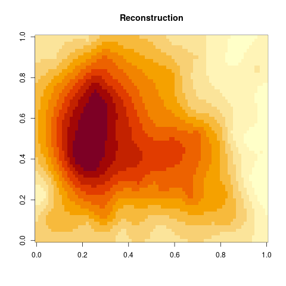

```r
image(pred, main="Reconstruction")
```

## Mappings

For various advanced purposes, such as computing likelihood profiles, it is useful to know the details of the parameterization of the models - the scale on which the parameters are defined (e.g. standard deviation, variance, or log-standard deviation for variance parameters) and their order.

### Unstructured

```r
vv0 <- VarCorr(fit.us)
vv1 <- vv0$cond$group          ## extract 'naked' V-C matrix
n <- nrow(vv1)
rpars <- getME(fit.us,"theta") ## extract V-C parameters
## first n parameters are log-std devs:
all.equal(unname(diag(vv1)),exp(rpars[1:n])^2)
```

```
## [1] TRUE
```

```r
## now try correlation parameters:
cpars <- rpars[-(1:n)]
length(cpars)==n*(n-1)/2      ## the expected number
```

```
## [1] TRUE
```

```r
cc <- diag(n)
cc[upper.tri(cc)] <- cpars
L <- crossprod(cc)
D <- diag(1/sqrt(diag(L)))
round(D %*% L %*% D,3)
```

```
##       [,1]  [,2]  [,3]  [,4]  [,5]  [,6]
## [1,] 1.000 0.353 0.273 0.166 0.160 0.108
## [2,] 0.353 1.000 0.384 0.216 0.192 0.136
## [3,] 0.273 0.384 1.000 0.352 0.239 0.195
## [4,] 0.166 0.216 0.352 1.000 0.354 0.273
## [5,] 0.160 0.192 0.239 0.354 1.000 0.345
## [6,] 0.108 0.136 0.195 0.273 0.345 1.000
```

```r
round(unname(attr(vv1,"correlation")),3)
```

```
##       [,1]  [,2]  [,3]  [,4]  [,5]  [,6]
## [1,] 1.000 0.353 0.273 0.166 0.160 0.108
## [2,] 0.353 1.000 0.384 0.216 0.192 0.136
## [3,] 0.273 0.384 1.000 0.352 0.239 0.195
## [4,] 0.166 0.216 0.352 1.000 0.354 0.273
## [5,] 0.160 0.192 0.239 0.354 1.000 0.345
## [6,] 0.108 0.136 0.195 0.273 0.345 1.000
```

```r
all.equal(c(cov2cor(vv1)),c(fit.us$obj$env$report(fit.us$fit$parfull)$corr[[1]]))
```

```
## [1] TRUE
```

Profiling (experimental/exploratory):

```r
## want $par, not $parfull: do NOT include conditional modes/'b' parameters
ppar <- fit.us$fit$par
length(ppar)
```

```
## [1] 22
```

```r
range(which(names(ppar)=="theta")) ## the last n*(n+1)/2 parameters
```

```
## [1]  2 22
```

```r
## only 1 fixed effect parameter
tt <- tmbprofile(fit.us$obj,2,trace=FALSE)
```

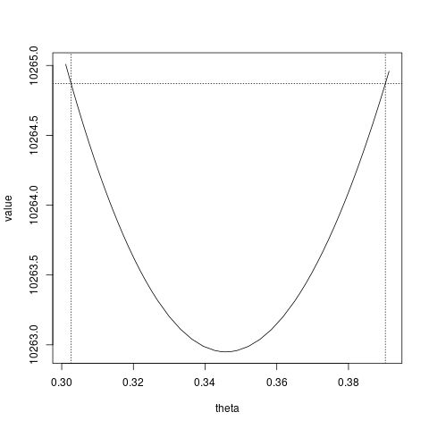

```r
confint(tt)
plot(tt)
```

[output not shown]

```r
ppar <- fit.cs$fit$par
length(ppar)
```

```
## [1] 8
```

```r
range(which(names(ppar)=="theta")) ## the last n*(n+1)/2 parameters
```

```
## [1] 2 8
```

```r
## only 1 fixed effect parameter, 1 dispersion parameter
tt2 <- tmbprofile(fit.cs$obj,3,trace=FALSE)
```

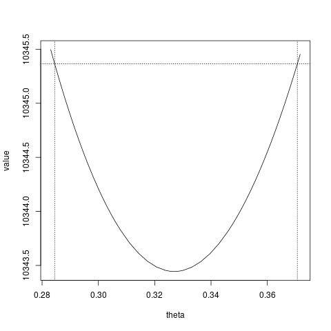

```r
plot(tt2)
```

## General latent variable model

Consider a generalized linear mixed model

$$\begin{equation}
g(\boldsymbol{\mu}) = \boldsymbol{X\beta} + \boldsymbol{Zb}
\end{equation}$$

where $g(.)$ is the link function; $\boldsymbol{\beta}$ is a p-dimensional vector of regression coefficients related to the covariates; $\boldsymbol{X}$ is an $n \times p$ model matrix; and $\boldsymbol{Z}$ is the $n\times q$ model matrix for the $q$-dimensional vector-valued random effects variable $\boldsymbol{U}$ which is multivariate normal with mean zero and a parameterized $q \times q$ variance-covariance matrix, $\boldsymbol{\Sigma}$, i.e., $\boldsymbol{U} \sim N(\boldsymbol{0}, \boldsymbol{\Sigma})$.

A general latent variable model (GLVM) requires many fewer parameters for the variance-covariance matrix, $\boldsymbol{\Sigma}$. To a fit a GLVM we add a *reduced-rank* (rr) covariance structure, so the model becomes
$$\begin{align}
g(\boldsymbol{\mu}) &= \boldsymbol{X\beta} + \boldsymbol{Z(I_n \otimes \Lambda)b} \\
&= \boldsymbol{X\beta} + \boldsymbol{Zb_{new}}
\end{align}$$
where $\otimes$ is the Kronecker product and $\boldsymbol{\Lambda} = (\boldsymbol{\lambda_1}, \ldots, \boldsymbol{\lambda_d})'$ is the $q \times d$ matrix of factor loadings (with $d \ll q$). The upper triangular elements of $\boldsymbol{\Lambda}$ are set to be zero to ensure parameter identifiability. Here we assume that the latent variables follow a multivariate standard normal distribution, $\boldsymbol{b} \sim N(\boldsymbol{0}, \boldsymbol{I})$.

For GLVMs it is important to select initial starting values for the parameters because the observed likelihood may be multimodal, and maximization algorithms can end up in local maxima. Niku et al. (2019) describe methods to enable faster and more reliable fits of latent variable models by carefully choosing starting values of the parameters.

A similar method has been implemented in `glmmTMB`. A generalized linear model is fitted to the data to obtain initial starting values for the fixed parameters in the model. Residuals from the fitted GLM are calculated; Dunn-Smyth residuals are calculated for common families while residuals from the `dev.resids()` function are used otherwise. Initial starting values for the latent variables and their loadings are obtained by fitting a reduced rank model to the residuals.

### Reduced rank

One of our main motivations for adding this variance-covariance structure is to enable the analysis of multivariate abundance data, for example to model the abundance of different taxa across multiple sites. Typically an unstructured random effect is assumed to account for correlation between taxa; however the number of parameters required quickly becomes large with increasing numbers of taxa. A GLVM is a flexible and more parsimonious way to account for correlation so that one can fit a joint model across many taxa.

A GLVM can be fit by specifying a reduced rank (`rr`) covariance structure. For example, the code for modeling the mean abundance against taxa and to account for the correlation between taxa using two latent variables is as follows

```r
fit.rr <- glmmTMB(abundance ~ taxa + rr(taxa + 0|site, d = 2))
```

The left hand side of the bar `taxa + 0` corresponds to a factor loading matrix that accounts for the correlations among taxa. The right hand side of the bar splits the above specification independently among sites. The `d` is a non-negative integer (which defaults to 2).

An option in `glmmTMBControl()` has been included to initialize the starting values for the parameters based on the approach mentioned above with the default set at `glmmTMBControl(start_method = list(method = NULL, jitter.sd = 0)`:

- `method = "res"` initializes starting values from the results of fitting a GLM, and fitting a reduced rank model to the residuals to obtain starting values for the fixed coefficients, the latent variables and the factor loadings.
- `jitter.sd` adds variation to the starting values of latent variables when `method = "res"` (default 0).

For a reduced rank matrix of rank `d`, parameters `1:d` represent the diagonal factor loadings while the remaining `$nd-d(d-3)/2$`, (i.e. `(d+1):(nd-d(d-1)/2`) are the lower diagonal factor loadings filled in column-wise order. The factor loadings from a model can be obtained by `fit.rr$obj$env$report(fit.rr$fit$parfull)$fact_load[[1]]`. The rank of the model can be determined by standard model selection approaches such as information criteria (e.g. AIC or BIC) (Hui et al. 2015).

## References

Hui, Francis KC, Sara Taskinen, Shirley Pledger, Scott D Foster, and David I Warton. 2015. “Model-Based Approaches to Unconstrained Ordination.” *Methods in Ecology and Evolution* 6 (4): 399–411. https://doi.org/https://doi.org/10.1111/2041-210X.12236.

Niku, Jenni, Francis K. C. Hui, Sara Taskinen, and David I. Warton. 2019. “Gllvm: Fast Analysis of Multivariate Abundance Data with Generalized Linear Latent Variable Models in R.” *Methods in Ecology and Evolution* 10 (12): 2173–82. https://doi.org/https://doi.org/10.1111/2041-210X.13303.